# Cyclistic - Data analysis project

Daniel R. Beckert

2024-01-19

## Objective

Document the analysis process performed for the Google Data Analytics Professional Certificate capstone project.

### Setup

To run this project you need to run the following commands if you don’t have `tidyverse`, `skimr` or `scales` installed.

```
install.packages('tidyverse')
install.packages('skimr')
install.packages('scales')
```

[output not shown]

### Load necessary information

```r
library('tidyverse')
library('skimr')
library('scales')
```

## Load datasets

Load all the data necessary to perform the analysis, we are assuming the data is on the `trips` directory on the same folder as this file

```r
trips_2022_11 <- read_csv('./trips/2022/11/202211-divvy-tripdata.csv')
trips_2022_12 <- read_csv('./trips/2022/12/202212-divvy-tripdata.csv')
trips_2023_01 <- read_csv('./trips/2023/01/202301-divvy-tripdata.csv')
trips_2023_02 <- read_csv('./trips/2023/02/202302-divvy-tripdata.csv')
trips_2023_03 <- read_csv('./trips/2023/03/202303-divvy-tripdata.csv')
trips_2023_04 <- read_csv('./trips/2023/04/202304-divvy-tripdata.csv')
trips_2023_05 <- read_csv('./trips/2023/05/202305-divvy-tripdata.csv')
trips_2023_06 <- read_csv('./trips/2023/06/202306-divvy-tripdata.csv')
trips_2023_07 <- read_csv('./trips/2023/07/202307-divvy-tripdata.csv')
trips_2023_08 <- read_csv('./trips/2023/08/202308-divvy-tripdata.csv')
trips_2023_09 <- read_csv('./trips/2023/09/202309-divvy-tripdata.csv')
trips_2023_10 <- read_csv('./trips/2023/10/202310-divvy-tripdata.csv')
```

## Prepare and process the data

```r
skim(trips_2022_11)
```

Data summary

| Name | trips_2022_11 |
| --- | --- |
| Number of rows | 337735 |
| Number of columns | 13 |
| _______________________ |  |
| Column type frequency: |  |
| character | 7 |
| numeric | 4 |
| POSIXct | 2 |
| ________________________ |  |
| Group variables | None |

**Variable type: character**

| skim_variable | n_missing | complete_rate | min | max | empty | n_unique | whitespace |
| --- | --- | --- | --- | --- | --- | --- | --- |
| ride_id | 0 | 1.00 | 16 | 16 | 0 | 337735 | 0 |
| rideable_type | 0 | 1.00 | 11 | 13 | 0 | 3 | 0 |
| start_station_name | 51957 | 0.85 | 10 | 49 | 0 | 1062 | 0 |
| start_station_id | 51957 | 0.85 | 3 | 35 | 0 | 1037 | 0 |
| end_station_name | 54259 | 0.84 | 10 | 49 | 0 | 1068 | 0 |
| end_station_id | 54259 | 0.84 | 3 | 35 | 0 | 1040 | 0 |
| member_casual | 0 | 1.00 | 6 | 6 | 0 | 2 | 0 |

**Variable type: numeric**

| skim_variable | n_missing | complete_rate | mean | sd | p0 | p25 | p50 | p75 | p100 | hist |
| --- | --- | --- | --- | --- | --- | --- | --- | --- | --- | --- |
| start_lat | 0 | 1 | 41.90 | 0.05 | 41.65 | 41.88 | 41.90 | 41.93 | 42.07 | ▁▁▇▆▁ |
| start_lng | 0 | 1 | -87.65 | 0.03 | -87.84 | -87.66 | -87.64 | -87.63 | -87.52 | ▁▁▇▇▁ |
| end_lat | 230 | 1 | 41.90 | 0.21 | 0.00 | 41.88 | 41.90 | 41.93 | 42.08 | ▁▁▁▁▇ |
| end_lng | 230 | 1 | -87.65 | 0.43 | -87.84 | -87.66 | -87.65 | -87.63 | 0.00 | ▇▁▁▁▁ |

**Variable type: POSIXct**

| skim_variable | n_missing | complete_rate | min | max | median | n_unique |
| --- | --- | --- | --- | --- | --- | --- |
| started_at | 0 | 1 | 2022-11-01 00:00:05 | 2022-11-30 23:56:11 | 2022-11-10 18:12:27 | 300238 |
| ended_at | 0 | 1 | 2022-11-01 00:03:50 | 2022-12-01 11:45:53 | 2022-11-10 18:26:30 | 300541 |

To perform the a standard cleaning process we will create a function. The cleaning process will remove columns that won’t be used during the analysis process, remove rows with missing values and fix problems where `ended_at` is before `started_at`

```r
clean_dataset <- function(dataset) {

  # Remove unnecessary columns
  ds_removed_columns <- select(
    dataset,
    -c(
      start_station_name,
      start_station_id,
      end_station_name,
      end_station_id,
      start_lat,
      start_lng,
      end_lat,
      end_lng
    )
  )

  # Remove missing values
  ds_removed_missing <- drop_na(ds_removed_columns)

  # Fix problem with dates
  ds_fixed_dates <- ds_removed_missing %>%
    mutate(
      new_started_at=if_else(started_at > ended_at, ended_at, started_at),
      new_ended_at=if_else(started_at > ended_at, started_at, ended_at),
      started_at=new_started_at,
      ended_at=new_ended_at
      ) %>%
    select(-new_started_at, -new_ended_at)

  return(ds_fixed_dates)
}
```

Create a single dataframe with all the data from the previous 12 files

```r
all_trips <- rbind(
  trips_2022_11,
  trips_2022_12,
  trips_2023_01,
  trips_2023_02,
  trips_2023_03,
  trips_2023_04,
  trips_2023_05,
  trips_2023_06,
  trips_2023_07,
  trips_2023_08,
  trips_2023_09,
  trips_2023_10,
  deparse.level = 0
)
```

Clean all the data

```r
all_trips_cleaned <- clean_dataset(all_trips)
```

Enrich our data computing the amount of minutes spent in each ride and also the day of the week

```r
all_trips_cleaned_enriched <- mutate(all_trips_cleaned, trip_in_minutes=as.numeric(difftime(ended_at, started_at, units="mins")))
all_trips_cleaned_enriched <- mutate(all_trips_cleaned_enriched, weekday=wday(started_at))
```

Remove outliers. Outliers are all those entries above the threshold of 97.5% of rides

```r
upper_bound <- quantile(all_trips_cleaned_enriched$trip_in_minutes, 0.975)

all_trips_filtered <- all_trips_cleaned_enriched %>%
  filter(trip_in_minutes <= upper_bound)
```

## Analyze the data

Identify how much each group represent on the total amount of rides

```r
trips_count_df<- all_trips_filtered %>%
  group_by(member_casual) %>%
  count() %>%
  ungroup() %>%
  mutate(percentage=`n` / sum(`n`)) %>%
  mutate(labels= scales::percent(percentage)) %>%
  rename(count=n)
```

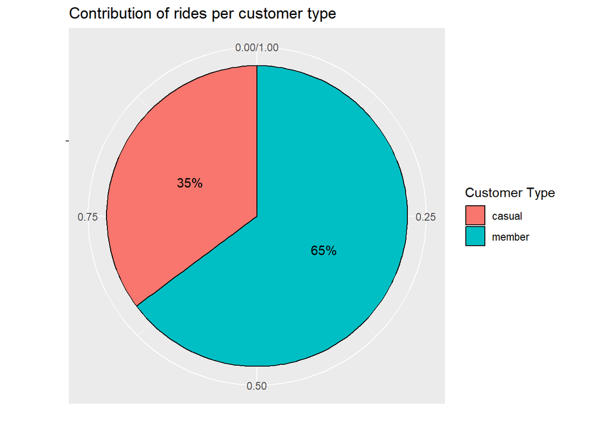

Identify how much each group represents in terms of time spent during rides

```r
trips_time_df<- all_trips_filtered %>%
  group_by(member_casual) %>%
  summarize(sum=sum(trip_in_minutes)) %>%
  ungroup() %>%
  mutate(percent=`sum` / sum(`sum`)) %>%
  mutate(labels= scales::percent(percent))
```

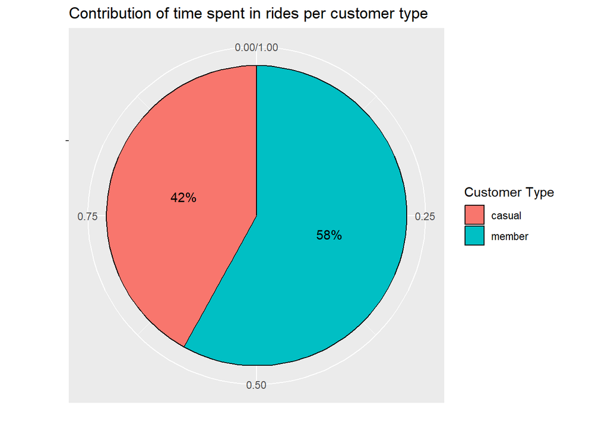

Check the average of time spent in each ride for each group

```r
average <- all_trips_filtered %>%
  group_by(member_casual) %>%
  summarize(avg=mean(trip_in_minutes))
```

```r
average
```

```
## # A tibble: 2 x 2
##   member_casual   avg
##   <chr>         <dbl>
## 1 casual         14.8
## 2 member         11.1
```

Analyze the distribution of rides throughout the year

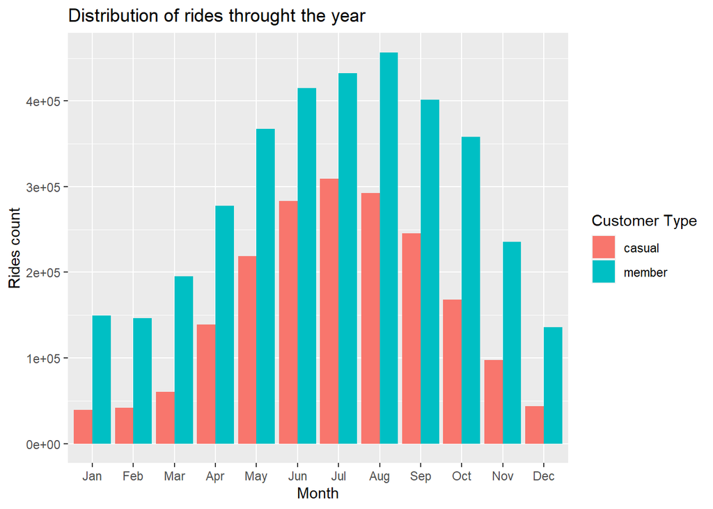

```r
ggplot(all_trips_filtered, aes(x=month(started_at, label=TRUE), fill=member_casual)) + geom_bar(position="dodge") +
  guides(fill=guide_legend(title="Customer Type")) +
  ggtitle("Distribution of rides throught the year") +
  labs(x="Month", y="Rides count")
```

Analyze the distribution of rides throughout the weekdays

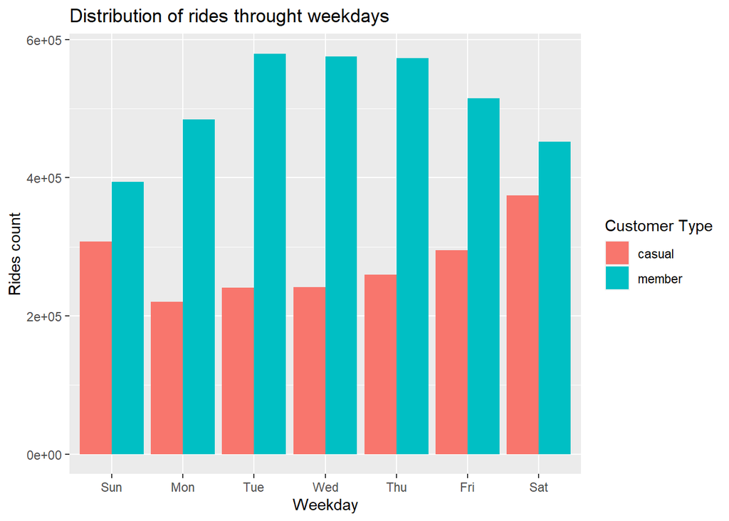

```r
ggplot(all_trips_filtered, aes(x=wday(started_at, label=TRUE), fill=member_casual)) +
  geom_bar(position="dodge") +
  guides(fill=guide_legend(title="Customer Type")) +
  ggtitle("Distribution of rides throught weekdays") +
  labs(x="Weekday", y="Rides count")
```

Analyze the distribution of rides throughout a day

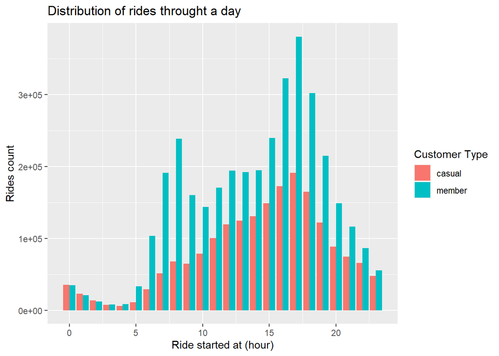

```r
ggplot(all_trips_filtered, aes(x=hour(started_at), fill=member_casual)) +
  geom_bar(position="dodge") +
  guides(fill=guide_legend(title="Customer Type")) +
  ggtitle("Distribution of rides throught a day") +
  labs(x="Ride started at (hour)", y="Rides count")
```

Analyze the distribution of rides in different days of the week

```r
all_trips_weekday <- all_trips_filtered %>%
  filter(weekday!=1 & weekday!=7)

all_trips_weekend <- all_trips_filtered %>%
  filter(weekday==1 | weekday==7)
```

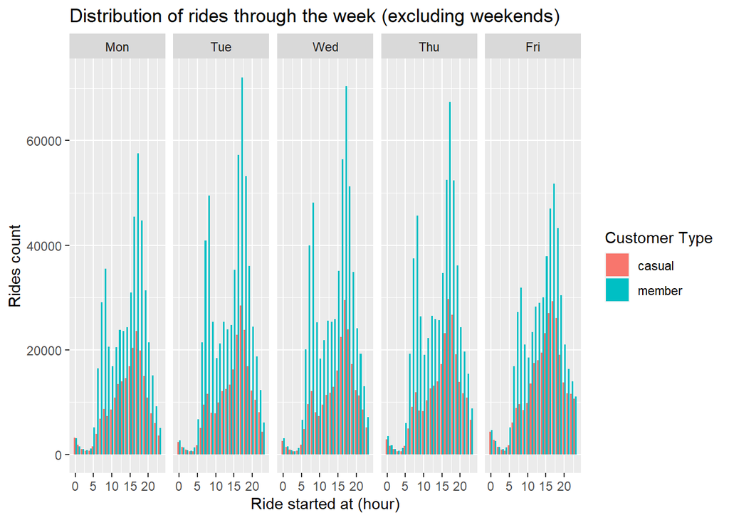

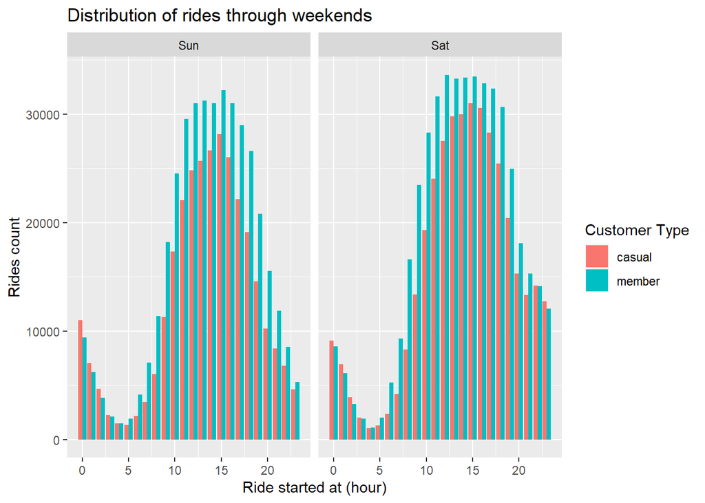